# Lab 1

## Class: MSDS 7331 Data Mining

## Dataset: Kaggle.com

COLLABORATORS: Rebecca Holsapple, Steven Cocke, Iram Bakhtiar

# 1. Business Understanding

In today's world, air travel is not just becoming more common for business and leisure trips, but is an integral part of the economy. Air travel has been consistently increasing the past few decades.

We believe that a thorough analysis and understanding of delays and cancellations of flights, can provide useful business recommendations to the airline industry and the passengers. To the passengers it helps in planning travel by avoiding airports, flight times, and seasons with heavy delays. For the airlines it provides useful information on bottlencks on the routes/in the air system and to forecast potential loss of revenues for passenger lodging/rerouting due to delayed or missed flights.

```python
import datetime, warnings, scipy
import time
import pandas as pd
import numpy as np
import seaborn as sns
import matplotlib as mpl
import matplotlib.pyplot as plt
import matplotlib.patches as patches
%matplotlib inline

from collections import OrderedDict
from matplotlib.patches import ConnectionPatch
from matplotlib.gridspec import GridSpec
from mpl_toolkits.basemap import Basemap
```

```python
# Bring in the data

Flights = pd.read_csv("C:/Users/DataScience/Documents/SMU/Data_Mining2/Lab1/Flight_Data/flights.csv", low_memory=False)
Airlines = pd.read_csv("C:/Users/DataScience/Documents/SMU/Data_Mining2/Lab1/Flight_Data/airlines.csv", low_memory=False)
Airports = pd.read_csv("C:/Users/DataScience/Documents/SMU/Data_Mining2/Lab1/Flight_Data/airports.csv", low_memory=False)
Regions =  pd.read_csv("C:/Users/DataScience/Documents/SMU/Data_Mining2/Lab1/Flight_Data/state_region.csv", low_memory=False)
```

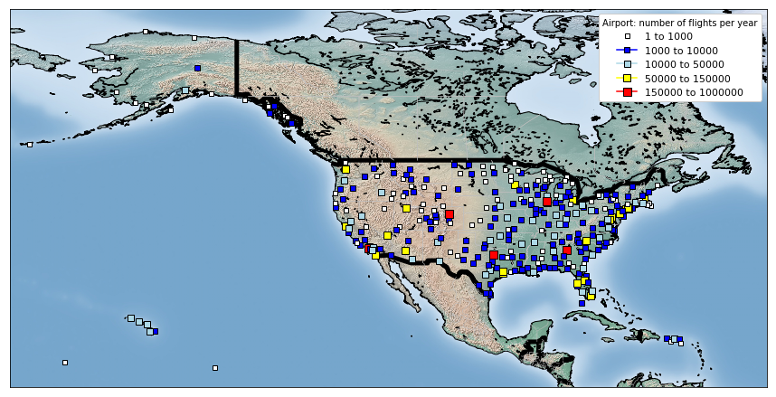

```python
import sys

if not sys.warnoptions:
    import warnings
    warnings.simplefilter("ignore")

count_flights = Flights['ORIGIN_AIRPORT'].value_counts()
plt.figure(figsize=(15,15))

colors = ['white', 'blue', 'lightblue', 'yellow', 'red', 'black']
flight_limits = [1, 1000, 10000, 50000, 150000, 1000000]

labels = []
for i in range(len(flight_limits) - 1):
    labels.append("{} to {}".format(flight_limits[i], flight_limits[i+1]))

map = Basemap(resolution = 'i',llcrnrlon = -180, urcrnrlon = -50,
              llcrnrlat = 10, urcrnrlat = 75, lat_0 = 0, lon_0 = 0,)
map.shadedrelief()
map.drawcoastlines()
map.drawcountries(linewidth = 5)
map.drawstates(color='0.75')

for index, (code, y, x) in Airports[['IATA_CODE', 'LATITUDE', 'LONGITUDE']].iterrows():
    x, y = map(x, y)
    isize = [i for i, val in enumerate(flight_limits) if val < count_flights[code]]
    ind = isize[-1]
    map.plot(x, y, marker='s', markersize = ind + 5, markeredgewidth = 1,
             color = colors[ind], markeredgecolor='k', label = labels[ind])

handles, labels = plt.gca().get_legend_handles_labels()
by_label = OrderedDict(zip(labels, handles))
key_order = ('1 to 1000', '1000 to 10000', '10000 to 50000', '50000 to 150000', '150000 to 1000000')
legend = OrderedDict()
for key in key_order:
    legend[key] = by_label[key]
plt.legend(legend.values(), legend.keys(), loc = 0, prop= {'size':11},
           title='Airport: number of flights per year', frameon = True, framealpha = 1)
plt.show()
```

# 2. Data Meaning Type

For the project our data comes from three datasets

1. The first has data on airlines. The dataset has 14 rows and 2 columns
2. The second has data on airports in the USA. It has 322 rows and 7 columns
3. And the last one has information on flights and it has 5.8M rows and 31 columns

To describe the meaning and type of data, we'll be making use of the data dictionary below that describes all the attributes that are in the three data sets being used for the lab. We'll also be using code that will show the number of rows and columns of each data set and if the values of the attributes are floats/integers/objects

# Data Dictionary

Below is the description of the attributes for each of the data sets used. For the purposes of this lab, we plan on taking an overall look at the data sets and provide insights at a higher level. The team has decided to continue using the same data sets to glean more meaningful and deeper insights, making use of modeling and machine learning for future labs.

### Flights

**YEAR** : Year of the Flight Trip  
**MONTH** : Month of the Flight Trip  
**DAY** : Day of the Flight Trip  
**DAY_OF_WEEK** : Day of week of the Flight Trip  
**AIRLINE** : Airline Code  
**FLIGHT_NUMBER** : Flight Number  
**TAIL_NUMBER** : Tail Number  
**ORIGIN_AIRPORT** : Origin airport code  
**DESTINATION_AIRPORT** : Destination airport code  
**SCHEDULED_DEPARTURE** : Scheduled departure time  
**SCHEDULED_ARRIVAL** : Scheduled arrival time  
**DEPARTURE_TIME** : Actual departure time  
**ARRIVAL_TIME** : Actual arrival time  
**DEPARTURE_DELAY** : Delay in departure times (in minutes)  
**ARRIVAL_DELAY** : Delay in arrival times (in minutes)  
**AIR_TIME, SCHEDULED_TIME, ELAPSED_TIME, DIVERTED** : Times of flight and whether it was diverted  
**DISTANCE** : Flight distance  
**AIR_SYSTEM_DELAY, SECURITY_DELAY, AIRLINE_DELAY, LATE_AIRCRAFT_DELAY, WEATHER_DELAY** : Possible types of delays  
**TAXI_IN, TAXI_OUT, WHEELS_OFF, WHEELS_ON** : Misc attributes  
**CANCELLED, CANCELLATION_REASON** : Whether flight was cancelled and reason

### Airlines

**IATA_CODE** - Airport IATA code  
**AIRLINE** - Airline name

### Airports

**IATA_CODE** - Airport IATA code  
**AIRPORT** - Airport  
**CITY, STATE, COUNTRY** - City, state, and country of airport  
**LATITUDE, LONGITUDE** - Latitude and longitude of airport

### Regions

**N** - North  
**W** - West  
**M** - Midwest  
**S** - South  
**O** - Other

```python
# Get the number of rows and columns in each data set

print (Airlines.shape)
print (Airports.shape)
print (Flights.shape)
```

```
(14, 2)
(322, 7)
(5819079, 31)
```

```python
Airports.info(verbose=True)
```

```
<class 'pandas.core.frame.DataFrame'>
RangeIndex: 322 entries, 0 to 321
Data columns (total 7 columns):
IATA_CODE    322 non-null object
AIRPORT      322 non-null object
CITY         322 non-null object
STATE        322 non-null object
COUNTRY      322 non-null object
LATITUDE     319 non-null float64
LONGITUDE    319 non-null float64
dtypes: float64(2), object(5)
memory usage: 17.7+ KB
```

#### The dataset Airports has a total of 322 records and 7 variables. It has all the pertinent information on geographical location of the airports (includes the city/state/country/longitude/latitude). It is noticed that both Latitude and Longitude attributes are missing 3 values with a toal count of records for each at 319 instead of 322. Below is an extraction of the first five records from the dataset.

```python
Airports.head()
```

|  | IATA_CODE | AIRPORT | CITY | STATE | COUNTRY | LATITUDE | LONGITUDE |
| --- | --- | --- | --- | --- | --- | --- | --- |
| 0 | ABE | Lehigh Valley International Airport | Allentown | PA | USA | 40.65236 | -75.44040 |
| 1 | ABI | Abilene Regional Airport | Abilene | TX | USA | 32.41132 | -99.68190 |
| 2 | ABQ | Albuquerque International Sunport | Albuquerque | NM | USA | 35.04022 | -106.60919 |
| 3 | ABR | Aberdeen Regional Airport | Aberdeen | SD | USA | 45.44906 | -98.42183 |
| 4 | ABY | Southwest Georgia Regional Airport | Albany | GA | USA | 31.53552 | -84.19447 |

```python
Airlines.info(verbose=True)
```

```
<class 'pandas.core.frame.DataFrame'>
RangeIndex: 14 entries, 0 to 13
Data columns (total 2 columns):
IATA_CODE    14 non-null object
AIRLINE      14 non-null object
dtypes: object(2)
memory usage: 304.0+ bytes
```

### The dataset Airlines has a total of 14 records and 2 variables. They are both categorical variables. Below is an extraction of the first five records from the dataset.

```python
Airlines.head()
```

|  | IATA_CODE | AIRLINE |
| --- | --- | --- |
| 0 | UA | United Air Lines Inc. |
| 1 | AA | American Airlines Inc. |
| 2 | US | US Airways Inc. |
| 3 | F9 | Frontier Airlines Inc. |
| 4 | B6 | JetBlue Airways |

```python
Flights.info(verbose=True)
```

```
<class 'pandas.core.frame.DataFrame'>
RangeIndex: 5819079 entries, 0 to 5819078
Data columns (total 31 columns):
YEAR                   int64
MONTH                  int64
DAY                    int64
DAY_OF_WEEK            int64
AIRLINE                object
FLIGHT_NUMBER          int64
TAIL_NUMBER            object
ORIGIN_AIRPORT         object
DESTINATION_AIRPORT    object
SCHEDULED_DEPARTURE    int64
DEPARTURE_TIME         float64
DEPARTURE_DELAY        float64
TAXI_OUT               float64
WHEELS_OFF             float64
SCHEDULED_TIME         float64
ELAPSED_TIME           float64
AIR_TIME               float64
DISTANCE               int64
WHEELS_ON              float64
TAXI_IN                float64
SCHEDULED_ARRIVAL      int64
ARRIVAL_TIME           float64
ARRIVAL_DELAY          float64
DIVERTED               int64
CANCELLED              int64
CANCELLATION_REASON    object
AIR_SYSTEM_DELAY       float64
SECURITY_DELAY         float64
AIRLINE_DELAY          float64
LATE_AIRCRAFT_DELAY    float64
WEATHER_DELAY          float64
dtypes: float64(16), int64(10), object(5)
memory usage: 1.3+ GB
```

### The Flights dataset has 5.8M records and 31 variables.The dataset contains all information on the flights that took place in the US airports in 2015. It includes data on the date/time of the flights, flight identifiers like flight and tail numbers, the airports they took off from and landed at, if there were any delays, the time spent in delays and the reason for delays, and if the flights were cancelled or diverted because of the delays.

### Below is an extraction of the first five records for all the attributes in the flights dataset

```python
Flights.head()
```

|  | YEAR | MONTH | DAY | DAY_OF_WEEK | AIRLINE | FLIGHT_NUMBER | TAIL_NUMBER | ORIGIN_AIRPORT | DESTINATION_AIRPORT | SCHEDULED_DEPARTURE | ... | ARRIVAL_TIME | ARRIVAL_DELAY | DIVERTED | CANCELLED | CANCELLATION_REASON | AIR_SYSTEM_DELAY | SECURITY_DELAY | AIRLINE_DELAY | LATE_AIRCRAFT_DELAY | WEATHER_DELAY |
| --- | --- | --- | --- | --- | --- | --- | --- | --- | --- | --- | --- | --- | --- | --- | --- | --- | --- | --- | --- | --- | --- |
| 0 | 2015 | 1 | 1 | 4 | AS | 98 | N407AS | ANC | SEA | 5 | ... | 408.0 | -22.0 | 0 | 0 | NaN | NaN | NaN | NaN | NaN | NaN |
| 1 | 2015 | 1 | 1 | 4 | AA | 2336 | N3KUAA | LAX | PBI | 10 | ... | 741.0 | -9.0 | 0 | 0 | NaN | NaN | NaN | NaN | NaN | NaN |
| 2 | 2015 | 1 | 1 | 4 | US | 840 | N171US | SFO | CLT | 20 | ... | 811.0 | 5.0 | 0 | 0 | NaN | NaN | NaN | NaN | NaN | NaN |
| 3 | 2015 | 1 | 1 | 4 | AA | 258 | N3HYAA | LAX | MIA | 20 | ... | 756.0 | -9.0 | 0 | 0 | NaN | NaN | NaN | NaN | NaN | NaN |
| 4 | 2015 | 1 | 1 | 4 | AS | 135 | N527AS | SEA | ANC | 25 | ... | 259.0 | -21.0 | 0 | 0 | NaN | NaN | NaN | NaN | NaN | NaN |

5 rows × 31 columns

# 3. Data Quality

Verify data quality: Explain any missing values, duplicate data, and outliers. Are those mistakes? How do you deal with these problems? Give justifications for your methods.

# Missing Values Analysis - Flights Dataset

```python
# Missing values Analysis

#Get the number of total records. Since flights is the biggest dataset, we'll check for missing data in it
length = len(Flights)

#Get percent NA and sort them
missing_values = Flights.isnull().sum()/length
missing_values = missing_values.sort_values(ascending=False)

#Filter out Attributes with less than 0.1% NAs
missing_values = missing_values[missing_values.values * 100 > .1].to_frame()

#Create useful information in columns
missing_values["Total_Missing"] = (length * missing_values).astype(int)
missing_values["Remaining"] = length - missing_values["Total_Missing"]

#Little bit of aesthetic cleanup
missing_values = missing_values.reset_index()
missing_values = missing_values.rename(columns = {0: "Percent_NA", "index":"Attribute"})
missing_values.columns.name = "Rank"

#Display
missing_values
```

| Rank | Attribute | Percent_NA | Total_Missing | Remaining |
| --- | --- | --- | --- | --- |
| 0 | CANCELLATION_REASON | 0.984554 | 5729195 | 89884 |
| 1 | WEATHER_DELAY | 0.817250 | 4755640 | 1063439 |
| 2 | AIRLINE_DELAY | 0.817250 | 4755640 | 1063439 |
| 3 | SECURITY_DELAY | 0.817250 | 4755640 | 1063439 |
| 4 | AIR_SYSTEM_DELAY | 0.817250 | 4755640 | 1063439 |
| 5 | LATE_AIRCRAFT_DELAY | 0.817250 | 4755640 | 1063439 |
| 6 | ARRIVAL_DELAY | 0.018056 | 105071 | 5714008 |
| 7 | AIR_TIME | 0.018056 | 105071 | 5714008 |
| 8 | ELAPSED_TIME | 0.018056 | 105071 | 5714008 |
| 9 | ARRIVAL_TIME | 0.015898 | 92513 | 5726566 |
| 10 | TAXI_IN | 0.015898 | 92513 | 5726566 |
| 11 | WHEELS_ON | 0.015898 | 92513 | 5726566 |
| 12 | WHEELS_OFF | 0.015303 | 89047 | 5730032 |
| 13 | TAXI_OUT | 0.015303 | 89047 | 5730032 |
| 14 | DEPARTURE_DELAY | 0.014805 | 86153 | 5732926 |
| 15 | DEPARTURE_TIME | 0.014805 | 86153 | 5732926 |
| 16 | TAIL_NUMBER | 0.002530 | 14721 | 5804358 |

```python
#turn index name 'Rank' into a column named 'index' so we can order the data easier
missing_values = missing_values.reset_index()
```

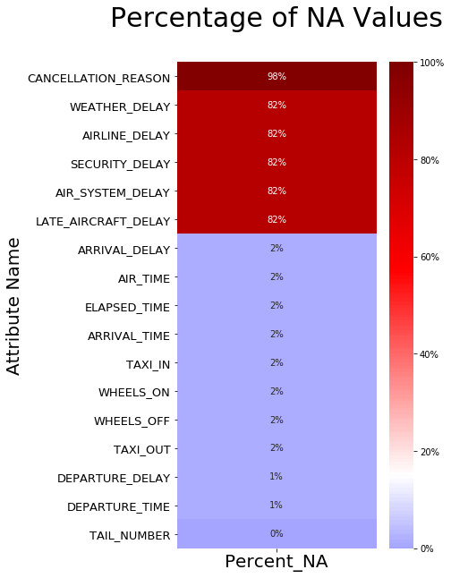

```python
from matplotlib.ticker import FuncFormatter

cutoff_percentage = .15

with sns.plotting_context(font_scale=5.5):
    plt.rcParams["figure.figsize"] = [5,10]
    fmtr = FuncFormatter(lambda x,pos: '{:.0%}'.format(x))

    piv = pd.pivot_table(missing_values,values="Percent_NA",index="index")
    ax = sns.heatmap(piv, square=False, cmap="seismic",
                     vmin=0,vmax=1, center=cutoff_percentage,fmt='.0%',
                     cbar_kws={'format': fmtr},
                     yticklabels=missing_values["Attribute"].tolist(), annot=True)

    ax.set_xlabel("",fontsize=30)
    ax.set_ylabel("Attribute Name",fontsize=20)
    ax.tick_params(labelsize=13)
    ax.tick_params(axis="x", labelsize = 20)
    ax.set_title(label="Percentage of NA Values\n")
    ax.title.set_size(30)

    plt.show()
```

### 17 of the 31 attributes (or a little over half of the attributes) have missing values. We have to stress that the above missing values analysis on the flights dataset can be a bit misleading for our data. In the sense that, the attributes that show a high percentage of missing data do not necessarily correlate with bad data or data that we may want to impute for. For e.g. 82% of the records are missing a value for the variable weather delay. And that is expected, since not all flights get delayed due to weather.

### In other words, these are not missing data due to the dataset being unclean, but because not all flights flying out of all airports at all times will be cancelled or delayed due to weather, security reasons, air system delays.

# Missing Values Analysis - Airlines Dataset

```python
missing_values = Airlines.isnull().sum()/len(Airlines)*100
missing_values = missing_values.sort_values(ascending=False)
missing_values
```

```
AIRLINE      0.0
IATA_CODE    0.0
dtype: float64
```

### The Airlines dataset has no missing values in either of its attributes. This was expected since each airline will be designated an IATA Code and a name. These are necessary identifiers.

# Missing Values Analysis - Airports Dataset

```python
missing_values = Airports.isnull().sum()/len(Airports)*100
missing_values = missing_values.sort_values(ascending=False)
missing_values
```

```
LONGITUDE    0.931677
LATITUDE     0.931677
COUNTRY      0.000000
STATE        0.000000
CITY         0.000000
AIRPORT      0.000000
IATA_CODE    0.000000
dtype: float64
```

```python
#Check for Missing values
missing_values = Airports.isnull().sum().reset_index()
missing_values.columns = ['Variable Name', 'Number Missing Values']
missing_values = missing_values[missing_values['Number Missing Values'] > 0]
missing_values
```

|  | Variable Name | Number Missing Values |
| --- | --- | --- |
| 5 | LATITUDE | 3 |
| 6 | LONGITUDE | 3 |

### Our Airports dataset is missing 3 values each for the Latitude and Longitutde attributes. Below is a table that shows which airports had the missing values for longitude and latitude and other geographic information related to the airports. For this lab's purposes we have decided not to delete them since in this lab we want to provide a high level overview/analysis of the three datasets used.

```python
# Code to see which rows have the null values
Airports.loc[Airports.isnull().any(axis=1)]
```

|  | IATA_CODE | AIRPORT | CITY | STATE | COUNTRY | LATITUDE | LONGITUDE |
| --- | --- | --- | --- | --- | --- | --- | --- |
| 96 | ECP | Northwest Florida Beaches International Airport | Panama City | FL | USA | NaN | NaN |
| 234 | PBG | Plattsburgh International Airport | Plattsburgh | NY | USA | NaN | NaN |
| 313 | UST | Northeast Florida Regional Airport (St. August... | St. Augustine | FL | USA | NaN | NaN |

# Outlier Analysis - Flights Dataset

```python
import math
import re
import statistics
from IPython.display import display, HTML

%matplotlib inline
```

```python
from scipy import stats

def getNumOfOutliers(row, avg, std, alpha=.05):
    x = 0
    for cell in row:
        if (cell>avg+std*stats.t.ppf(1-alpha, 999)) or (cell<avg-std*stats.t.ppf(1-alpha, 999)):
            x=x+1
    return x

def getNumOfZeroes(row):
    x = 0
    for cell in row:
        if cell==0:
            x=x+1
    return x
```

```python
outlier_plot = Flights.loc[:,Flights.dtypes==float].columns

outlier_mean = Flights[outlier_plot].apply(lambda row: statistics.mean(row))

outlier_data = pd.DataFrame(data={'mean':outlier_mean},index=outlier_plot)

outlier_data['std'] = Flights[outlier_plot].apply(lambda row: statistics.stdev(row))
```

[output not shown]

[output cut: 15 more lines]

[output not shown]

```python
outlier_data['NumberOfOutliers'] = Flights[outlier_plot].apply(lambda row: getNumOfOutliers(row, statistics.mean(row),statistics.stdev(row),.001 ))
outlier_data['NumberOfExtremeOutliers'] = Flights[outlier_plot].apply(lambda row: getNumOfOutliers(row, statistics.mean(row),statistics.stdev(row),.0000000000000001 ))
```

```python
outlier_data['NumberOfZeroes'] = Flights[outlier_plot].apply(lambda row: getNumOfZeroes(row))
outlier_data['PctOfZeroes'] = Flights[outlier_plot].apply(lambda row: getNumOfZeroes(row)/Flights.shape[0])
```

```python
outlier_data = outlier_data.sort_values(by='NumberOfOutliers',ascending=False)
display(HTML(outlier_data.head(10).to_html()))
```

```python
plt.figure(figsize = (8,6))
sns.heatmap(outlier_data[['NumberOfOutliers','NumberOfExtremeOutliers','NumberOfZeroes']].corr(),linewidths=0.5, annot=True);
```

### The code for analysing outliers did not render. It is extremely compute intensive, especially keeping in mind the size of our dataset. We were hoping to see if there was a correlation between enumber of outliers and number of zeroes. In the interst of time and keeping in mind that this is a prelim analysis of the datasets, we have decided to include the code. We will run the outliers analysis in future labs.

# 4. Simple Statistics

Visualize appropriate statistics (e.g., range, mode, mean, median, variance, counts) for a subset of attributes. Describe anything meaningful you found from this or if you found something potentially interesting. Note: You can also use data from other sources for comparison. Explain why the statistics run are meaningful.

### We will we be running simple statistics on the flights dataset only since the airports and airlines datasets have metadata and won't have any value for running simple statistics

```python
import statistics
```

```python
Flights.describe().transpose()
```

|  | count | mean | std | min | 25% | 50% | 75% | max |
| --- | --- | --- | --- | --- | --- | --- | --- | --- |
| YEAR | 5819079.0 | 2015.000000 | 0.000000 | 2015.0 | 2015.0 | 2015.0 | 2015.0 | 2015.0 |
| MONTH | 5819079.0 | 6.524085 | 3.405137 | 1.0 | 4.0 | 7.0 | 9.0 | 12.0 |
| DAY | 5819079.0 | 15.704594 | 8.783425 | 1.0 | 8.0 | 16.0 | 23.0 | 31.0 |
| DAY_OF_WEEK | 5819079.0 | 3.926941 | 1.988845 | 1.0 | 2.0 | 4.0 | 6.0 | 7.0 |
| FLIGHT_NUMBER | 5819079.0 | 2173.092742 | 1757.063999 | 1.0 | 730.0 | 1690.0 | 3230.0 | 9855.0 |
| SCHEDULED_DEPARTURE | 5819079.0 | 1329.602470 | 483.751821 | 1.0 | 917.0 | 1325.0 | 1730.0 | 2359.0 |
| DEPARTURE_TIME | 5732926.0 | 1335.204439 | 496.423260 | 1.0 | 921.0 | 1330.0 | 1740.0 | 2400.0 |
| DEPARTURE_DELAY | 5732926.0 | 9.370158 | 37.080942 | -82.0 | -5.0 | -2.0 | 7.0 | 1988.0 |
| TAXI_OUT | 5730032.0 | 16.071662 | 8.895574 | 1.0 | 11.0 | 14.0 | 19.0 | 225.0 |
| WHEELS_OFF | 5730032.0 | 1357.170841 | 498.009356 | 1.0 | 935.0 | 1343.0 | 1754.0 | 2400.0 |
| SCHEDULED_TIME | 5819073.0 | 141.685892 | 75.210582 | 18.0 | 85.0 | 123.0 | 173.0 | 718.0 |
| ELAPSED_TIME | 5714008.0 | 137.006189 | 74.211072 | 14.0 | 82.0 | 118.0 | 168.0 | 766.0 |
| AIR_TIME | 5714008.0 | 113.511628 | 72.230822 | 7.0 | 60.0 | 94.0 | 144.0 | 690.0 |
| DISTANCE | 5819079.0 | 822.356495 | 607.784287 | 21.0 | 373.0 | 647.0 | 1062.0 | 4983.0 |
| WHEELS_ON | 5726566.0 | 1471.468609 | 522.187945 | 1.0 | 1054.0 | 1509.0 | 1911.0 | 2400.0 |
| TAXI_IN | 5726566.0 | 7.434971 | 5.638548 | 1.0 | 4.0 | 6.0 | 9.0 | 248.0 |
| SCHEDULED_ARRIVAL | 5819079.0 | 1493.808249 | 507.164696 | 1.0 | 1110.0 | 1520.0 | 1918.0 | 2400.0 |
| ARRIVAL_TIME | 5726566.0 | 1476.491188 | 526.319737 | 1.0 | 1059.0 | 1512.0 | 1917.0 | 2400.0 |
| ARRIVAL_DELAY | 5714008.0 | 4.407057 | 39.271297 | -87.0 | -13.0 | -5.0 | 8.0 | 1971.0 |
| DIVERTED | 5819079.0 | 0.002610 | 0.051020 | 0.0 | 0.0 | 0.0 | 0.0 | 1.0 |
| CANCELLED | 5819079.0 | 0.015446 | 0.123320 | 0.0 | 0.0 | 0.0 | 0.0 | 1.0 |
| AIR_SYSTEM_DELAY | 1063439.0 | 13.480568 | 28.003679 | 0.0 | 0.0 | 2.0 | 18.0 | 1134.0 |
| SECURITY_DELAY | 1063439.0 | 0.076154 | 2.143460 | 0.0 | 0.0 | 0.0 | 0.0 | 573.0 |
| AIRLINE_DELAY | 1063439.0 | 18.969547 | 48.161642 | 0.0 | 0.0 | 2.0 | 19.0 | 1971.0 |
| LATE_AIRCRAFT_DELAY | 1063439.0 | 23.472838 | 43.197018 | 0.0 | 0.0 | 3.0 | 29.0 | 1331.0 |
| WEATHER_DELAY | 1063439.0 | 2.915290 | 20.433336 | 0.0 | 0.0 | 0.0 | 0.0 | 1211.0 |

```python
# Change date of week from numbers to days
Flights.YEAR.unique() #2015
day_of_week_desc={
    1:'Monday',
    2:'Tuesday',
    3:'Wednesday',
    4:'Thursday',
    5:'Friday',
    6:'Saturday',
    7:'Sunday'
}
Flights['DAYS_OF_WEEK']=Flights['DAY_OF_WEEK'].apply(lambda a:day_of_week_desc[a])
Flights.head()['DAYS_OF_WEEK']
```

```
0    Thursday
1    Thursday
2    Thursday
3    Thursday
4    Thursday
Name: DAYS_OF_WEEK, dtype: object
```

```python
Flights.head()
```

[output not shown]

5 rows × 34 columns

```python
# Change months from numbers to days
Flights.YEAR.unique() #2015
month_desc={
    1:'Jan',
    2:'Feb',
    3:'Mar',
   4:'Apr',
    5:'May',
    6:'Jun',
    7:'Jul',
    8:'Aug',
    9:'Sep',
   10:'Oct',
    11:'Nov',
    12:'Dec'
}
Flights['Month_Names']=Flights['MONTH'].apply(lambda a:month_desc[a])
Flights.head()['Month_Names']
```

```
0    Jan
1    Jan
2    Jan
3    Jan
4    Jan
Name: Month_Names, dtype: object
```

```python
# Adding year month day to get date e.g 2015-01-01
Flights['DATE'] = pd.to_datetime(Flights[['YEAR','MONTH', 'DAY']])
```

```python
Flights.head()
```

|  | YEAR | MONTH | DAY | DAY_OF_WEEK | AIRLINE | FLIGHT_NUMBER | TAIL_NUMBER | ORIGIN_AIRPORT | DESTINATION_AIRPORT | SCHEDULED_DEPARTURE | ... | CANCELLED | CANCELLATION_REASON | AIR_SYSTEM_DELAY | SECURITY_DELAY | AIRLINE_DELAY | LATE_AIRCRAFT_DELAY | WEATHER_DELAY | DAYS_OF_WEEK | Month_Names | DATE |
| --- | --- | --- | --- | --- | --- | --- | --- | --- | --- | --- | --- | --- | --- | --- | --- | --- | --- | --- | --- | --- | --- |
| 0 | 2015 | 1 | 1 | 4 | AS | 98 | N407AS | ANC | SEA | 5 | ... | 0 | NaN | NaN | NaN | NaN | NaN | NaN | Thursday | Jan | 2015-01-01 |
| 1 | 2015 | 1 | 1 | 4 | AA | 2336 | N3KUAA | LAX | PBI | 10 | ... | 0 | NaN | NaN | NaN | NaN | NaN | NaN | Thursday | Jan | 2015-01-01 |
| 2 | 2015 | 1 | 1 | 4 | US | 840 | N171US | SFO | CLT | 20 | ... | 0 | NaN | NaN | NaN | NaN | NaN | NaN | Thursday | Jan | 2015-01-01 |
| 3 | 2015 | 1 | 1 | 4 | AA | 258 | N3HYAA | LAX | MIA | 20 | ... | 0 | NaN | NaN | NaN | NaN | NaN | NaN | Thursday | Jan | 2015-01-01 |
| 4 | 2015 | 1 | 1 | 4 | AS | 135 | N527AS | SEA | ANC | 25 | ... | 0 | NaN | NaN | NaN | NaN | NaN | NaN | Thursday | Jan | 2015-01-01 |

5 rows × 34 columns

```python
import statistics
```

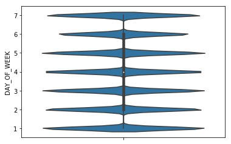

```python
sns.violinplot( y=Flights["DAY_OF_WEEK"] )
```

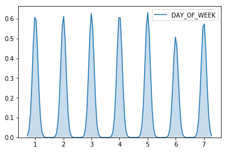

```python
sns.kdeplot(Flights["DAY_OF_WEEK"], shade=True)
```

**There appears to an approximately equal number of flights during the week on Monday through Friday. However, there appears to be a significant decrease number of flights occurring on Saturday with a small increase on Sunday. The possible indication for the higher number of flights during the week could be due to the business travelers flight to and from nationwide offices or due to ticket price dropping in the middle of the week. The Saturday and Sunday decrease may perhaps be an indication that less people travel during non-business days.**

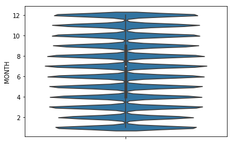

```python
sns.violinplot( y=Flights["MONTH"] )
```

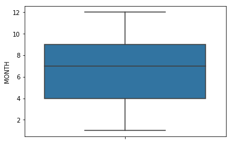

```python
sns.boxplot( y=Flights["MONTH"] )
```

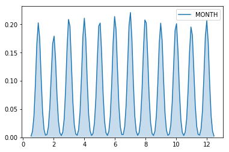

```python
sns.kdeplot(Flights["MONTH"], shade=True)
```

**It seems flight trends tend to increase beginning in the Spring which could be coincide with Spring Break most University and K-12 receive time off from school during this time so there is an opportunity for families to travel. The trend looks to dip slight in May, when most school in session then increase again in June. July is the height for flights which also follows along with he school session due to schools in most parts of the country being about for summer break. There is a noticeable decrease in August and continuing through the Fall when schools are back in session. The Flight rebound slightly in December and January but decrease drastically in February.**

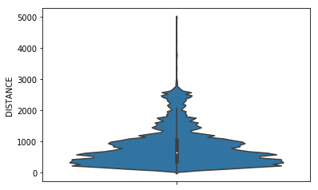

```python
sns.violinplot( y=Flights["DISTANCE"] )
```

**The largest amount of flights occurred below 700 miles then drops off drastically over 1300 miles**

# 5. Visualize Attributes

Visualize the most interesting attributes (at least 5 attributes, your opinion on what is interesting). Important: Interpret the implications for each visualization. Explain for each attribute why the chosen visualization is appropriate.

Before we create the graphics we need to clean up and transform some data values. The code blocks below are being used for cleaning and reformatting data

```python
import matplotlib
matplotlib.style.use('ggplot')
from subprocess import check_output
```

```python
#air system delay
Flights2 = Flights.loc[(Flights['AIR_SYSTEM_DELAY'] != False, ['ARRIVAL_DELAY'])]

delays_airsys = Flights.loc[(Flights['AIR_SYSTEM_DELAY'] > 0, ['ARRIVAL_DELAY'])].sum()
notdelayed_airsys = Flights.loc[(Flights['AIR_SYSTEM_DELAY'] <= 0, ['ARRIVAL_DELAY'])].sum()

count_sys = Flights2[(Flights['AIR_SYSTEM_DELAY'] != False)].count()
count_sys_pos =Flights.loc[(Flights['AIR_SYSTEM_DELAY'] > 0, ['ARRIVAL_DELAY'])].count()
```

```python
# security delay
Flights2 = Flights.loc[(Flights['SECURITY_DELAY'] != False, ['ARRIVAL_DELAY'])]

delays_airsec = Flights.loc[(Flights['SECURITY_DELAY'] > 0, ['ARRIVAL_DELAY'])].sum()
notdelayed_airsec = Flights.loc[(Flights['SECURITY_DELAY'] <= 0, ['ARRIVAL_DELAY'])].sum()

count_sec = Flights2[(Flights['SECURITY_DELAY'] != False)].count()
count_sec_pos = Flights.loc[(Flights['SECURITY_DELAY'] > 0, ['ARRIVAL_DELAY'])].count()
```

```python
#airline delay
Flights2 = Flights.loc[(Flights['AIRLINE_DELAY'] != False, ['ARRIVAL_DELAY'])]

delays_airair = Flights.loc[(Flights['AIRLINE_DELAY'] > 0, ['ARRIVAL_DELAY'])].sum()
notdelayed_airair = Flights.loc[(Flights['AIRLINE_DELAY'] <= 0, ['ARRIVAL_DELAY'])].sum()

count_air = Flights2[(Flights['AIRLINE_DELAY'] != False)].count()
count_air_pos = Flights.loc[(Flights['AIRLINE_DELAY'] > 0, ['ARRIVAL_DELAY'])].count()
```

```python
# late arrival delay
Flights2 = Flights.loc[(Flights['LATE_AIRCRAFT_DELAY'] != False, ['ARRIVAL_DELAY'])]

delays_airlate = Flights.loc[(Flights['LATE_AIRCRAFT_DELAY'] > 0, ['ARRIVAL_DELAY'])].sum()
notdelayed_airlate = Flights.loc[(Flights['LATE_AIRCRAFT_DELAY'] <= 0, ['ARRIVAL_DELAY'])].sum()

count_late = Flights2[(Flights['LATE_AIRCRAFT_DELAY'] != False)].count()
count_late_pos = Flights.loc[(Flights['LATE_AIRCRAFT_DELAY'] > 0, ['ARRIVAL_DELAY'])].count()
```

```python
# weather delay
Flights2 = Flights.loc[(Flights['WEATHER_DELAY'] != False, ['ARRIVAL_DELAY'])]

delays_airweather = Flights.loc[(Flights['WEATHER_DELAY'] > 0, ['ARRIVAL_DELAY'])].sum()
notdelayed_airweather = Flights.loc[(Flights['WEATHER_DELAY'] <= 0, ['ARRIVAL_DELAY'])].sum()

count_weather = Flights2[(Flights['WEATHER_DELAY'] != False)].count()
count_weather_pos = Flights.loc[(Flights['WEATHER_DELAY'] > 0, ['ARRIVAL_DELAY'])].count()
```

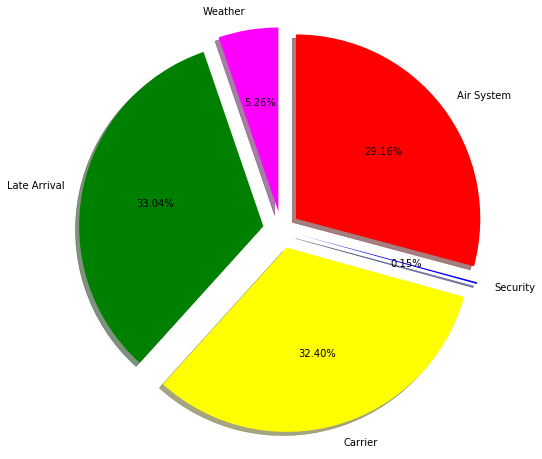

```python
labels = 'Weather', 'Late Arrival', 'Carrier', 'Security', 'Air System'
sizes = [delays_airweather, delays_airlate, delays_airair, delays_airsec, delays_airsys]
explode = (0.1, 0.1, 0.1, 0.1, 0.1)
colors=['magenta','green','yellow','blue','red']

fig1, ax1 = plt.subplots(figsize=(8,8))
ax1.pie(sizes, colors=colors,labels=labels, autopct='%1.2f%%',
        shadow=True, explode=explode, startangle=90, center=(0,0))
ax1.axis('equal')


plt.show()
```

### The above pie chart shows visually the reasons for delays for flights in US in 2015. Late arrival accounted for 33% of the delays in flights in 2015. Late arrival is defined as the same aircraft arriving late at a previous airport and delaying the flights downstream.

### This was closely followed by flights being delayed because of the carrier that may be caused by time taken for aircraft cleaning &B maintenance, waiting for connecting passengers, cargo loading, or slow boarding of passengers and putting away carry-on luggage to name a few.

### Air system had the 3rd most impact on delays. This would include any and all areas that may impact the delay caused by volume of traffic at an airport, reduction in runways available, weather conditions enroute etc.

### Contrary to what we had imagined, weather did not impact the delays as much.

# 6. Explore Joint Attributes

Visualize relationships between attributes: Look at the attributes via scatter plots, correlation, cross-tabulation, group-wise averages, etc. as appropriate. Explain any interesting relationships

```python
#Merge airports and regions so that the states (and airports) are associated with a region
sns.set(style="ticks", color_codes=True)
airports_regions = pd.merge(Airports, Regions, on='STATE', how='left')
airports_regions.sort_values(by='IATA_CODE')
airports_regions_final = airports_regions[['IATA_CODE','REGION']]
```

```python
#Merge once for the Origin Region
flights_regions_single = pd.merge(Flights, airports_regions_final, left_on='ORIGIN_AIRPORT', right_on='IATA_CODE')
#Rename column
flights_regions_single.rename(columns={'REGION':'ORIGIN_REGION'}, inplace=True)
#Merge twice for the Destination Region
flights_regions_double = pd.merge(flights_regions_single, airports_regions_final, left_on='DESTINATION_AIRPORT', right_on='IATA_CODE')
#Drop extra columns from the merges
flights_regions = flights_regions_double.drop(['IATA_CODE_x', 'IATA_CODE_y'], axis=1)
#Rename column
flights_regions.rename(columns={'REGION':'DESTINATION_REGION'}, inplace=True)
#Sort dataframe based upon month, day, day of week, and departure time
flights_regions_final = flights_regions.sort_values(['MONTH', 'DAY', 'DAY_OF_WEEK','SCHEDULED_DEPARTURE'], ascending=[True, True, True, True])
#Run the line below to see the data at this point
#flights_regions_final
```

**A variable of interest is that of regions. Each airport is associated with a state, and each state is associated with a region. We merged two documents containing these pieces of information to associate each airport with a region. Exploratory analysis is conducted on flights that are and are not associated with region changes (i.e. N-N or S-N).**

```python
##Create a dataframe of only delayed flights
delayed_flights_only = flights_regions_final
is_delayed = delayed_flights_only['ARRIVAL_DELAY'] > 0
delayed_flights_only = delayed_flights_only[is_delayed]
```

```python
#Create a function to label different target classes Delayed-3 or Cancelled-1 or Diverted-2, others = 0
def f(row):
    if row['CANCELLED'] == 1:
        val = 'Cancelled'
    elif row['DIVERTED'] == 1:
        val = 'Diverted'
    elif row['ARRIVAL_DELAY'] > 0:
        val = 'Delayed'
    else:
        val = 'Unaffected'
    return val

#Run function on our dataset
flights_regions_final['DELAYED_OR_CANCELLED'] = flights_regions_final.apply(f, axis=1)

#Print out columns so that continuous attributes may be selected
print(flights_regions_final.columns)
scatter_columns = ['SCHEDULED_DEPARTURE', 'DEPARTURE_TIME', 'DEPARTURE_DELAY', 'TAXI_OUT',
       'WHEELS_OFF', 'SCHEDULED_TIME', 'ELAPSED_TIME', 'AIR_TIME', 'DISTANCE',
       'WHEELS_ON', 'TAXI_IN', 'SCHEDULED_ARRIVAL', 'ARRIVAL_TIME',
       'ARRIVAL_DELAY', 'DELAYED_OR_CANCELLED']
scatter_columns_delay = ['SCHEDULED_DEPARTURE', 'DEPARTURE_TIME', 'DEPARTURE_DELAY', 'TAXI_OUT',
       'WHEELS_OFF', 'SCHEDULED_TIME', 'ELAPSED_TIME', 'AIR_TIME', 'DISTANCE',
       'WHEELS_ON', 'TAXI_IN', 'SCHEDULED_ARRIVAL', 'ARRIVAL_TIME',
       'ARRIVAL_DELAY']
```

```
Index(['YEAR', 'MONTH', 'DAY', 'DAY_OF_WEEK', 'AIRLINE', 'FLIGHT_NUMBER',
       'TAIL_NUMBER', 'ORIGIN_AIRPORT', 'DESTINATION_AIRPORT',
       'SCHEDULED_DEPARTURE', 'DEPARTURE_TIME', 'DEPARTURE_DELAY', 'TAXI_OUT',
       'WHEELS_OFF', 'SCHEDULED_TIME', 'ELAPSED_TIME', 'AIR_TIME', 'DISTANCE',
       'WHEELS_ON', 'TAXI_IN', 'SCHEDULED_ARRIVAL', 'ARRIVAL_TIME',
       'ARRIVAL_DELAY', 'DIVERTED', 'CANCELLED', 'CANCELLATION_REASON',
       'AIR_SYSTEM_DELAY', 'SECURITY_DELAY', 'AIRLINE_DELAY',
       'LATE_AIRCRAFT_DELAY', 'WEATHER_DELAY', 'DAYS_OF_WEEK', 'Month_Names',
       'DATE', 'ORIGIN_REGION', 'DESTINATION_REGION', 'DELAYED_OR_CANCELLED'],
      dtype='object')
```

```python
#The following commented code took too long to run, but it was to create a scatterplot matrix
#sb.pairplot(flights_regions_final[scatter_columns], kind="scatter")
#scatter_matrix(flights_regions_final_sample[scatter_columns])
#plt.show()

#Function to create heatmap of correlations
def heatMap(df, mirror):

    # Create Correlation df
    corr = df.corr()
    # Plot figsize
    fig, ax = plt.subplots(figsize=(10, 10))
    # Generate Color Map
    colormap = sns.diverging_palette(220, 10, as_cmap=True)

    if mirror == True:
       #Generate Heat Map, allow annotations and place floats in map
       sns.heatmap(corr, cmap=colormap, annot=True, fmt=".2f")
       #Apply xticks
       plt.xticks(range(len(corr.columns)), corr.columns);
       #Apply yticks
       plt.yticks(range(len(corr.columns)), corr.columns)
       #show plot

    else:
       # Drop self-correlations
       dropSelf = np.zeros_like(corr)
       dropSelf[np.triu_indices_from(dropSelf)] = True# Generate Color Map
       colormap = sns.diverging_palette(220, 10, as_cmap=True)
       # Generate Heat Map, allow annotations and place floats in map
       sns.heatmap(corr, cmap=colormap, annot=True, fmt=".2f", mask=dropSelf)
       # Apply xticks
       plt.xticks(range(len(corr.columns)), corr.columns);
       # Apply yticks
       plt.yticks(range(len(corr.columns)), corr.columns)
    # show plot
    plt.show()
```

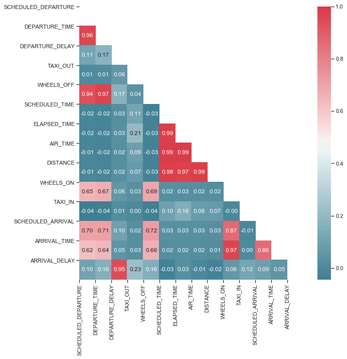

```python
#Call heatMap for all flights with the specified continuous variables
heatMap(flights_regions_final[scatter_columns], False)
```

**The heat map correlation results are just as we would expect them to be. Variables that are obviously related to arrival delays are highly correlated with it. Other variables are correlated to each other that also make sense, such as wheels on and scheduled arrival.**

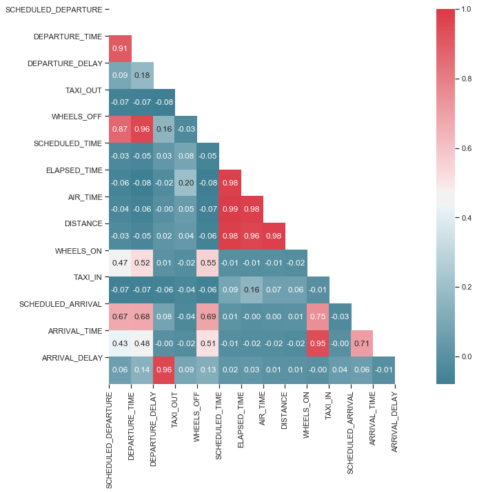

```python
#Call heatMap for only delayed flights with the specified continuous variables
heatMap(delayed_flights_only[scatter_columns_delay], False)
```

**The results here for delayed flights are essentially the same for all flights**

# 7. Explore Attribute Class

Identify and explain interesting relationships between features and the class you are trying to predict (i.e., relationships with variables and the target classification)

```python
##Region Change Arrival and Departure Delays

#Create binary variable to indicate if a region change occurred during flight
flights_regions_final['REGION_CHANGE'] = np.where(flights_regions_final['ORIGIN_REGION'] == flights_regions_final['DESTINATION_REGION'], 0, 1)

#Add to delayed flights
delayed_flights_only = flights_regions_final
is_delayed = delayed_flights_only['ARRIVAL_DELAY'] > 0
delayed_flights_only = delayed_flights_only[is_delayed]
```

**The below code shows different arrival and departure delays medians and means for several attributes: REGION_CHANGE, REGIONS_COMBINED, and PART_OF_DAY, all of which were created. They are displayed for all flights, and only delayed flights.**

```python
#Look at mean and median Arrival and Departure Delays grouped by new Region_Change variable

flights_regions_final.groupby('REGION_CHANGE', as_index=False)['DEPARTURE_DELAY'].median()

#flights_regions_final.groupby('REGION_CHANGE', as_index=False)['DEPARTURE_DELAY'].mean()
# We ran into technical issues where the code is not rendering all the information. Please uncomment to run the mean
```

[output not shown]

```python
#Look at mean and median Arrival and Departure Delays grouped by new Region_Change variable
flights_regions_final.groupby('REGION_CHANGE', as_index=False)['ARRIVAL_DELAY'].median()
#flights_regions_final.groupby('REGION_CHANGE', as_index=False)['ARRIVAL_DELAY'].mean()

# We ran into technical issues where the code is not rendering all the information. Please uncomment to run the mean
```

|  | REGION_CHANGE | ARRIVAL_DELAY |
| --- | --- | --- |
| 0 | 0 | -4.0 |
| 1 | 1 | -5.0 |

```python
#Look at mean and median Arrival and Departure Delays grouped by new Region_Change variable for
#delayed flights only

delayed_flights_only.groupby('REGION_CHANGE', as_index=False)['DEPARTURE_DELAY'].median()
#delayed_flights_only.groupby('REGION_CHANGE', as_index=False)['DEPARTURE_DELAY'].mean()

# We ran into technical issues where the code is not rendering all the information. Please uncomment to run the mean
```

|  | REGION_CHANGE | DEPARTURE_DELAY |
| --- | --- | --- |
| 0 | 0 | 12.0 |
| 1 | 1 | 15.0 |

```python
#Look at mean and median Arrival and Departure Delays grouped by new Region_Change variable for
#delayed flights only
delayed_flights_only.groupby('REGION_CHANGE', as_index=False)['ARRIVAL_DELAY'].median()
#delayed_flights_only.groupby('REGION_CHANGE', as_index=False)['ARRIVAL_DELAY'].mean()

# We ran into technical issues where the code is not rendering all the information. Please uncomment to run the mean
```

|  | REGION_CHANGE | ARRIVAL_DELAY |
| --- | --- | --- |
| 0 | 0 | 14.0 |
| 1 | 1 | 16.0 |

```python
#Combine Arrival and Departure Regions to create one variable that captures both
flights_regions_final['Regions_Combined'] = flights_regions_final.ORIGIN_REGION.map(str) + "-" + flights_regions_final.DESTINATION_REGION

#Add to delayed flights
delayed_flights_only = flights_regions_final
is_delayed = delayed_flights_only['ARRIVAL_DELAY'] > 0
delayed_flights_only = delayed_flights_only[is_delayed]
```

```python
#Mean and Median by new combined region variable
#flights_regions_final.groupby('Regions_Combined', as_index=False)['DEPARTURE_DELAY'].mean()
flights_regions_final.groupby('Regions_Combined', as_index=False)['DEPARTURE_DELAY'].median()
```

|  | Regions_Combined | DEPARTURE_DELAY |
| --- | --- | --- |
| 0 | M-M | -2.0 |
| 1 | M-N | -1.0 |
| 2 | M-O | 1.0 |
| 3 | M-S | -1.0 |
| 4 | M-W | -1.0 |
| 5 | N-M | -2.0 |
| 6 | N-N | -2.0 |
| 7 | N-O | 0.0 |
| 8 | N-S | -1.0 |
| 9 | N-W | -1.0 |
| 10 | O-M | 1.0 |
| 11 | O-N | -1.0 |
| 12 | O-O | -4.0 |
| 13 | O-S | -2.0 |
| 14 | O-W | -3.0 |
| 15 | S-M | -1.0 |
| 16 | S-N | -1.0 |
| 17 | S-O | 0.0 |
| 18 | S-S | -2.0 |
| 19 | S-W | -1.0 |
| 20 | W-M | -1.0 |
| 21 | W-N | -1.0 |
| 22 | W-O | -1.0 |
| 23 | W-S | -1.0 |
| 24 | W-W | -2.0 |

```python
#Mean and Median by new combined region variable

#flights_regions_final.groupby('Regions_Combined', as_index=False)['ARRIVAL_DELAY'].mean()
flights_regions_final.groupby('Regions_Combined', as_index=False)['ARRIVAL_DELAY'].median()
```

|  | Regions_Combined | ARRIVAL_DELAY |
| --- | --- | --- |
| 0 | M-M | -5.0 |
| 1 | M-N | -5.0 |
| 2 | M-O | -2.0 |
| 3 | M-S | -5.0 |
| 4 | M-W | -5.0 |
| 5 | N-M | -6.0 |
| 6 | N-N | -5.0 |
| 7 | N-O | -3.0 |
| 8 | N-S | -7.0 |
| 9 | N-W | -7.0 |
| 10 | O-M | -6.0 |
| 11 | O-N | -6.0 |
| 12 | O-O | -2.0 |
| 13 | O-S | -8.0 |
| 14 | O-W | -7.0 |
| 15 | S-M | -5.0 |
| 16 | S-N | -4.0 |
| 17 | S-O | -1.0 |
| 18 | S-S | -5.0 |
| 19 | S-W | -6.0 |
| 20 | W-M | -5.0 |
| 21 | W-N | -7.0 |
| 22 | W-O | -3.0 |
| 23 | W-S | -4.0 |
| 24 | W-W | -4.0 |

```python
#Same but for only delayed flights

#Mean and Median by new combined region variable for delayed flights only
delayed_flights_only.groupby('Regions_Combined', as_index=False)['DEPARTURE_DELAY'].mean()

#delayed_flights_only.groupby('Regions_Combined', as_index=False)['DEPARTURE_DELAY'].median()
# We ran into technical issues where the code is not rendering all the information. Please uncomment to run the mean
```

|  | Regions_Combined | DEPARTURE_DELAY |
| --- | --- | --- |
| 0 | M-M | 31.133637 |
| 1 | M-N | 37.942427 |
| 2 | M-O | 29.307749 |
| 3 | M-S | 33.255286 |
| 4 | M-W | 32.657529 |
| 5 | N-M | 36.820713 |
| 6 | N-N | 34.231063 |
| 7 | N-O | 33.550259 |
| 8 | N-S | 34.458820 |
| 9 | N-W | 33.332228 |
| 10 | O-M | 39.094536 |
| 11 | O-N | 40.572736 |
| 12 | O-O | 11.922819 |
| 13 | O-S | 36.190507 |
| 14 | O-W | 25.368832 |
| 15 | S-M | 33.122027 |
| 16 | S-N | 35.712661 |
| 17 | S-O | 30.540687 |
| 18 | S-S | 29.646026 |
| 19 | S-W | 32.170811 |
| 20 | W-M | 30.541863 |
| 21 | W-N | 34.528459 |
| 22 | W-O | 22.010130 |
| 23 | W-S | 28.136206 |
| 24 | W-W | 27.022268 |

```python
#Same but for only delayed flights

#Mean and Median by new combined region variable for delayed flights only

delayed_flights_only.groupby('Regions_Combined', as_index=False)['ARRIVAL_DELAY'].mean()

#delayed_flights_only.groupby('Regions_Combined', as_index=False)['ARRIVAL_DELAY'].median()

# We ran into technical issues where the code is not rendering all the information. Please uncomment to run the mean
```

|  | Regions_Combined | ARRIVAL_DELAY |
| --- | --- | --- |
| 0 | M-M | 36.245757 |
| 1 | M-N | 39.858238 |
| 2 | M-O | 32.662731 |
| 3 | M-S | 36.359114 |
| 4 | M-W | 34.836271 |
| 5 | N-M | 40.456645 |
| 6 | N-N | 37.672971 |
| 7 | N-O | 37.176905 |
| 8 | N-S | 38.591555 |
| 9 | N-W | 36.987939 |
| 10 | O-M | 37.902862 |
| 11 | O-N | 41.697091 |
| 12 | O-O | 16.399445 |
| 13 | O-S | 36.054337 |
| 14 | O-W | 29.313796 |
| 15 | S-M | 35.892151 |
| 16 | S-N | 38.302008 |
| 17 | S-O | 32.224945 |
| 18 | S-S | 32.722424 |
| 19 | S-W | 32.961549 |
| 20 | W-M | 33.153965 |
| 21 | W-N | 35.593606 |
| 22 | W-O | 28.275725 |
| 23 | W-S | 31.017550 |
| 24 | W-W | 29.225818 |

```python
#Create a function to label different times of the day Morning, Afternoon, Evening
def t(row):
    if row['SCHEDULED_DEPARTURE'] <= 1100:
        val = 'Morning'
    elif row['SCHEDULED_DEPARTURE'] > 1100 and row['SCHEDULED_DEPARTURE'] <= 1700:
        val = 'Afternoon'
    else:
        val = 'Evening'
    return val

#Run function on our dataset
flights_regions_final['PART_OF_DAY'] = flights_regions_final.apply(t, axis=1)
#Sort the data again
flights_regions_final = flights_regions_final.sort_values(['MONTH', 'DAY', 'DAY_OF_WEEK','SCHEDULED_DEPARTURE'], ascending=[True, True, True, True])
```

```python
#Add to delayed flights
delayed_flights_only = flights_regions_final
is_delayed = delayed_flights_only['ARRIVAL_DELAY'] > 0
delayed_flights_only = delayed_flights_only[is_delayed]

#Mean and Median by new part of day variable
#flights_regions_final.groupby('PART_OF_DAY', as_index=False)['DEPARTURE_DELAY'].mean()
flights_regions_final.groupby('PART_OF_DAY', as_index=False)['DEPARTURE_DELAY'].median()
```

|  | PART_OF_DAY | DEPARTURE_DELAY |
| --- | --- | --- |
| 0 | Afternoon | -1.0 |
| 1 | Evening | 0.0 |
| 2 | Morning | -3.0 |

```python
#Mean and Median by new part of day variable


#Mean and Median by new part of day variable for delayed flights only
#delayed_flights_only.groupby('PART_OF_DAY', as_index=False)['DEPARTURE_DELAY'].mean()
delayed_flights_only.groupby('PART_OF_DAY', as_index=False)['DEPARTURE_DELAY'].median()
```

|  | PART_OF_DAY | DEPARTURE_DELAY |
| --- | --- | --- |
| 0 | Afternoon | 15.0 |
| 1 | Evening | 20.0 |
| 2 | Morning | 4.0 |

```python
#Mean and Median by new part of day variable for delayed flights only

#delayed_flights_only.groupby('PART_OF_DAY', as_index=False)['ARRIVAL_DELAY'].mean()
delayed_flights_only.groupby('PART_OF_DAY', as_index=False)['ARRIVAL_DELAY'].median()
```

|  | PART_OF_DAY | ARRIVAL_DELAY |
| --- | --- | --- |
| 0 | Afternoon | 15.0 |
| 1 | Evening | 20.0 |
| 2 | Morning | 11.0 |

**Code below creates various scatterplots and box plots to examine relationships among variables, as well as a relationship between variables and the target prediction. Distributions can be examined for skewness in the boxplots. Where applicable, a log scale is used for ARRIVAL_DELAY, so that the graph is more interpretable. The title of each graph displays what attributes are plotted, and if there is a scale change.**

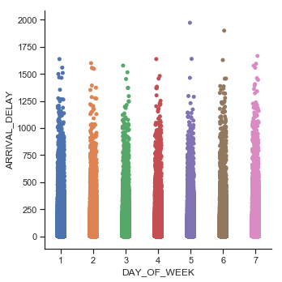

```python
##Scatterplot of Day of Week vs Arrival Delay
sns.catplot(x="DAY_OF_WEEK", y="ARRIVAL_DELAY", data=delayed_flights_only)
```

### The graph above shows that each day of the week has the same distribution of arrival delays.

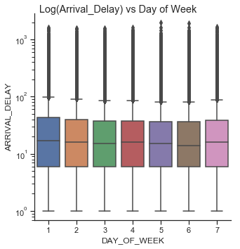

```python
#Boxplot of Day of Week vs log(Arrival Delay) for delayed flights only
g = sns.catplot(x="DAY_OF_WEEK", y="ARRIVAL_DELAY", kind="box", data=delayed_flights_only)
g.fig.get_axes()[0].set_yscale('log')
g.fig.suptitle('Log(Arrival_Delay) vs Day of Week')
plt.show()
```

### The box-plot confirms the same findings as above that there is no difference in distribution of delays across the week days.

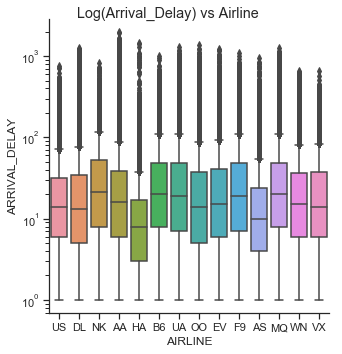

```python
#Boxplot of Airline vs log(Arrival Delay) of delayed flights only
g = sns.catplot(x="AIRLINE", y="ARRIVAL_DELAY", kind="box",
            data=delayed_flights_only);
g.fig.get_axes()[0].set_yscale('log')
g.fig.suptitle('Log(Arrival_Delay) vs Airline')
plt.show()
```

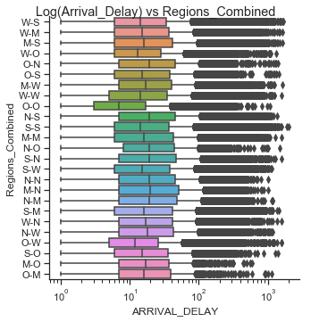

```python
#Boxplot of Regions Combined vs log(Arrival Delay) of delayed flights only
g = sns.catplot(x="ARRIVAL_DELAY", y="Regions_Combined", kind="box",
            data=delayed_flights_only)
g.fig.get_axes()[0].set_xscale('log')
g.fig.suptitle('Log(Arrival_Delay) vs Regions_Combined')
plt.show()
```

### The above graph shows the distributions of arrival delays for every region combination. Like the previous graphs, we see the O-O having the lowest arrival delays

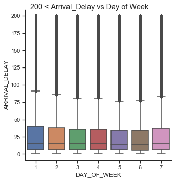

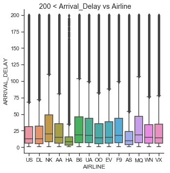

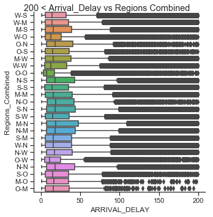

```python
#Repeat for only Arrival Delays below 200 minutes
#Boxplots ARRIVAL_DELAY < 200

#Grab only <200 delayed flights
delayed_flights_only_200 = delayed_flights_only
less_200 = delayed_flights_only_200['ARRIVAL_DELAY'] < 200
delayed_flights_only_200 = delayed_flights_only_200[less_200]

#Boxplot of Day of Week vs Arrival Delay for flights with <200 minute delays only
g = sns.catplot(x="DAY_OF_WEEK", y="ARRIVAL_DELAY", kind="box",
            data=delayed_flights_only_200)
g.fig.suptitle('200 < Arrival_Delay vs Day of Week')
plt.show()

#Boxplot of Airline vs Arrival Delay for flights with <200 minute delays only
g = sns.catplot(x="AIRLINE", y="ARRIVAL_DELAY", kind="box",
            data=delayed_flights_only_200)
g.fig.suptitle('200 < Arrival_Delay vs Airline')
plt.show()

#Boxplot of Regions Combined vs Arrival Delay for flights with <200 minute delays only
g = sns.catplot(x="ARRIVAL_DELAY", y="Regions_Combined", kind="box",
            data=delayed_flights_only_200)
g.fig.suptitle('200 < Arrival_Delay vs Regions Combined')
plt.show()
```

**The cell below displays the same graphs from above, but only for flights where the ARRIVAL_DELAY was less than 200 minutes. Accoring to the boxplots, 75% of the data is 200 or less, so examining this is useful.**

```python
#Define categories for Arrival Delay times
cats = ['0-100', '101-200', '201-300', '301-400', '401-500', '500+']
bins = [0, 100, 200, 300, 400, 500, 2000]

#Create bins and counts for each airline by the defined arrival delay bin
binned_airline_delays = (delayed_flights_only.groupby(['AIRLINE', pd.cut(delayed_flights_only['ARRIVAL_DELAY'], bins, labels=cats)])
         .size()
         .unstack(fill_value=0))
#Display bins and counts
print(binned_airline_delays)
```

```
ARRIVAL_DELAY   0-100  101-200  201-300  301-400  401-500  500+
AIRLINE
AA             212166    13161     2687      749      272   534
AS              50447     1593      282       83       21    25
B6              84665     7282     1455      319       94    34
DL             217672    12507     2937      963      376   544
EV             180040    13548     3111      830      246   135
F9              34600     2893      693      276      111   111
HA              27514      297       72       24        6    21
MQ              89212     7544     1345      350      155   161
NK              46741     4737      888      191       56    21
OO             189953    12380     2298      645      249   246
UA             156544    13570     3100      838      274   171
US              72357     3172      559      153       31    13
VX              20758     1156      275       45        7     3
WN             413214    21984     3887      772      158    37
```

**The cells below attempt to get a numerical summary for related variables. Flight arrival delays are binned and then counts are gathered. This helps in the visualization process**.

```python
#Create bins and counts for each region change by the defined arrival delay bin
binned_regionchange_delays = (delayed_flights_only.groupby(['Regions_Combined', pd.cut(delayed_flights_only['ARRIVAL_DELAY'], bins, labels=cats)])
         .size()
         .unstack(fill_value=0))
#Display bins and counts
print(binned_regionchange_delays)
```

```
ARRIVAL_DELAY      0-100  101-200  201-300  301-400  401-500  500+
Regions_Combined
M-M                79548     5751     1250      343      125   122
M-N                36161     3298      674      136       30    15
M-O                 1274       60       12        3        3     3
M-S                85398     6181     1387      377      113   141
M-W                66963     4415      929      256       94    85
N-M                33512     2997      674      213       72    25
N-N                38874     3134      657      154       44    17
N-O                 4612      314       61       13        4    10
N-S               103240     8463     1821      451      158   110
N-W                42655     3081      757      177       41    52
O-M                 1076       49       11        6        4     7
O-N                 3874      265       73       18        6    26
O-O                28552      503       88       23        3     9
O-S                 5648      325       71       37        9    20
O-W                12891      556      131       50       21    51
S-M                86282     6242     1374      372      117   125
S-N               113325     9686     1880      459      124    99
S-O                 8401      475       98       30        6    10
S-S               350676    21955     4534     1247      399   454
S-W               105939     6631     1358      338      108   109
W-M                65664     4095      820      270       98    95
W-N                42394     3002      658      160       30    51
W-O                17202      647      190       63       28    33
W-S               112937     5836     1239      327      165   181
W-W               348785    17863     2842      715      254   206
```

[figure not shown]

```python
##Box plots by region and airline combined over arrival_delay
g = sns.catplot(x="ARRIVAL_DELAY", y="Regions_Combined", row="AIRLINE",
                kind="box", orient="h", height=5, aspect=4,
                data=delayed_flights_only)
g.set(xscale="log")
plt.show()
```

**The boxplots are usefull to compare several attributes at once. In this case, region_combined and airline are combined in one box plot against arrival delays.**

# 8. New Features

Are there other features that could be added to the data or created from existing features? Which ones?

All new features that were created are examined in sections 6 and 7, for reference. New features that were created from the data include:

```
1. Adding a new variable to indicate whether a region change took place or not
during a flight (binary)
2. Adding a new variable to indicate what specific (if any) region change occurred during a flight (i.e. N-N, S-N, etc)
3. Adding a new variable to indicate whether a flight was delayed, diverted, cancelled, or none of the above (0-3)
```

New features that could be added to the data could possibly be weather data, as well as getting some differences between existing variables.

# 9. Exceptional Work

Provide additional analyses. One idea: implement dimensionality reduction, then visualize and interpret the results.

```python
from sklearn.preprocessing import StandardScaler
flights_regions_final.isna().sum()
features = ['SCHEDULED_DEPARTURE',
        'SCHEDULED_TIME', 'DISTANCE', 'SCHEDULED_ARRIVAL']
flights_regions_final.dropna(axis=0, subset=['SCHEDULED_TIME'], inplace = True)

# Separating out the features
x = flights_regions_final.loc[:, features].values
# Separating out the target
y = flights_regions_final.loc[:,['DELAYED_OR_CANCELLED']].values
# Standardizing the features
x = StandardScaler().fit_transform(x)
```

```python
#import PCA from sklearn and assign PCA variables

from sklearn.decomposition import PCA
pca = PCA(n_components=2)
principalComponents = pca.fit_transform(x)
principalDf = pd.DataFrame(data = principalComponents
             , columns = ['principal component 1', 'principal component 2'])

finalDf = pd.concat([principalDf, flights_regions_final[['DELAYED_OR_CANCELLED']]], axis = 1)
finalDf_sample = finalDf.sample(frac=.01, random_state=1, axis=0)
```

```python
#Define target values for comparisons, as well as graph colors
targets = ['Cancelled', 'Diverted', 'Delayed', 'Unaffected']
colors = ['r', 'g', 'b', 'y']
#Define indices to keep for graphing upon comparison
indicesToKeep = finalDf_sample['DELAYED_OR_CANCELLED'].isin(targets)
```

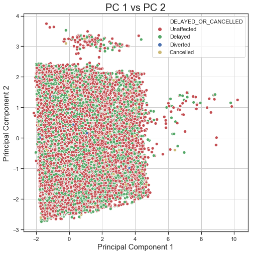

```python
#Create PCA Plot
fig = plt.figure(figsize = (8,8))
ax = sns.scatterplot(x="principal component 1", y="principal component 2", data=finalDf_sample, hue='DELAYED_OR_CANCELLED', palette=colors )

ax.set_title('PC 1 vs PC 2', fontsize = 20)
ax.set_xlabel('Principal Component 1', fontsize = 15)
ax.set_ylabel('Principal Component 2', fontsize = 15)
#ax.legend(targets)
ax.grid()
plt.show()
```

### PC1 contains more variability than PC2 and this can be seen from the axis range. The only attributes used in PCA analysis were continuous variables that provided information about a flight before the flight took place (i.e. only scheduled attributes and not actual flight data).

### The majority of the points represent unaffected or delayed flights mainly because only a few are ever diverted or cancelled.